# Selecting and presenting graphs in R.

# Introduction

*vpstheme* is designed to help R users in the Vicorian Public Service produce *gglot2* objects that comply with Brand Victoria and departmental guidelines simply.

This vignette was written for staff in the Department of Health.

This vignette is a compliment to and is informed by the departmental guidlines `'Selecting and presenting graphs Guidelines for departmental staff and graphic designers'` that can be found on the departmental intranet.

This vignette assumes the reader is familiar with making graphs in r using the *ggplot2* package, such as the example below.

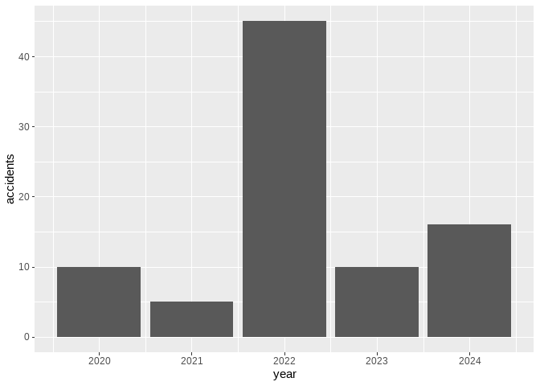

```r
library(vpstheme)

# Create tibble of data for example
car_accidents =
  tibble::tibble(
    year = c(2020,2021,2022,2023,2024),
    accidents = c(10,   5,  45, 10, 16))

# Create basic example of a column plot
ggplot(
  data = car_accidents,
  aes(x = year, y = accidents)
  ) +
  geom_col()
```

# Using theme_vps_dh

A theme comprises information on the colours, fonts and line styles you want the base of your plot to use. *vpstheme* exports several themes including `theme_vps_dh()`.

We can add `theme_vps_dh()` to a plot to implement many of the requirements of the departmental guidelines as shown below.

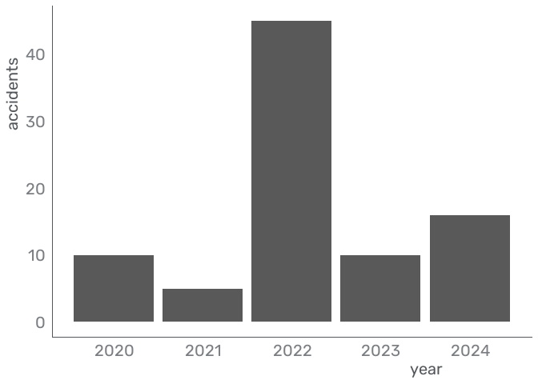

```r
# Add theme_vps_dh() to last_plot()
last_plot() +
  theme_vps_dh()
```

## 1. Graph titles, subtitles and captions.

> Note: Departmental guidelines require the graph title and its figure number be included as text in the document the graph is placed in – not on the graph artwork as shown here. This section is only to illustrate styles.

We can add titles, subtitles and captions to ggplot objects using `labs()` as shown below. As we have applied `theme_vps_dh()`, these additions comply with the departmental guidelines requirement that the title be placed in top left so it can be read before the y-axis label.

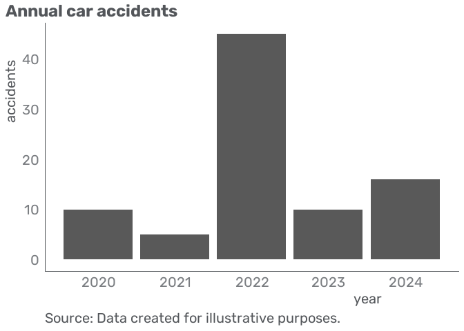

```r
# Add title and caption to last_plot()
last_plot() +
  labs(title = "Annual car accidents",
       caption = "Source: Data created for illustrative purposes.")
```

You should choose a title that gives a clear idea what the graph is about.

- You should consider information presented in axis labels when choosing a title. For example, axis labels (tick-mark labels) may explain the time category enough to preclude the need for this in the title.

> Note: Source/notes should also be included as text in the document the graph is placed in – not on the graph artwork as shown here.

## 2. Axis titles

We can set the value of axis titles using `labs()` or `scale_*_*()` functions. The latter has some advantages.

To set the value of the Y-axis title in the example below we have used `scale_y_continuvps()` as this *vpstheme* function adjusts the expansion value to achieve white spacing consistent with departmental guideleines as well as allowing us to a value for name.

The Y-axis title should be top left so it is read before the axis labels.

This is achieved in `theme_vps_dh` by setting `hjust = .8` for axis.text.y via `element_text()`. This shifts the axis title justification to be closer to the top of the axis.

Axis titles may not be needed if the graph title and the tick mark labels provide sufficient information. As seen in the example, the X-axis title is not shown as each column is obviously a year value. This adjustment is made by setting `x = NULL` in `labs()` or `name = NULL` in `scale_x_*()` rather than being a feature of `theme_vps_dh.`

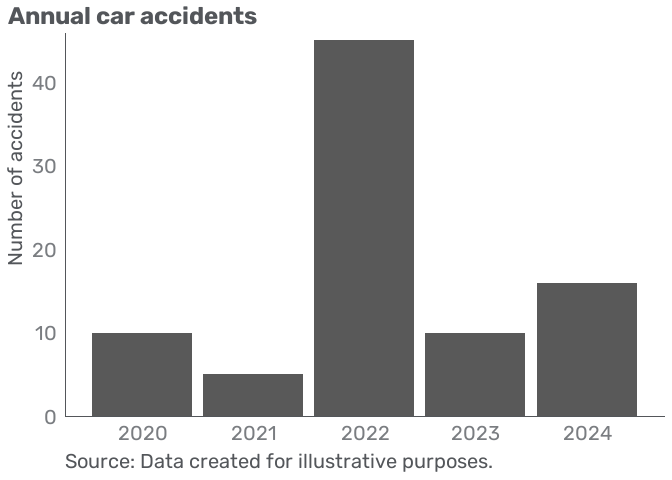

```r
# Add (or revove) names using scale functions.
last_plot() +
  scale_x_continuous(name = NULL) +
  scale_y_continuvps(name = "Number of accidents")
```

## 3. Axis labels

Departmental guidance requires axis labels be muted (light) relative to the data so they don’t overwhelm, or detract from, the message/story.

This is achieved in `theme_vps_dh()` using the `lighten()`function from the *colorspace* package. The axis labels are 25 per cent lighter than the default text (for white backgrounds).

Only use as many labels as necessary for the graph to be interpreted and use values that represent equal numeric intervals. The default values selected by ggplot largely meet these requirements.

We can improve labels in this example, by setting the limits of the y-axis to `c(0,50)` to ensure we have at least one label above our largest data value, noting `scale_y_continuvps(0` automatically adds enough space to ensure the axis line extends beyond the last label.

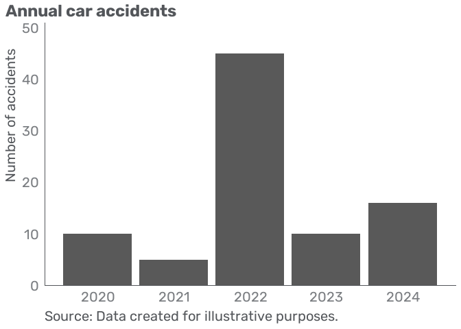

```r
# Add limits to scal_y_*
last_plot() +
  scale_y_continuvps(name = "Number of accidents", limits = c(0,50))
```

```r
# Assign this plot a name for later use
accident_plot = last_plot()
```

Departmental guidelines suggest avoiding rotating axis labels.Rotate the graph (instead of the text) if x-axis (categorical) labels are too long to fit side-by-side. We do this using `coord_flip()` as shown in the example below.

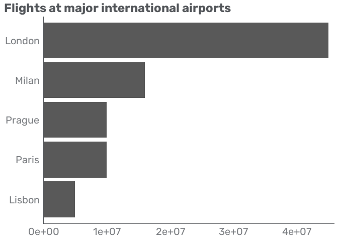

```r
# Create data tibble
airport_flights =
  tibble::tibble(
    city = c("London",  "Milan",    "Paris",    "Prague",   "Lisbon"),
    flights = c(45e6, 16e6,  10e6, 10e6, 5e6)
  )

# Create plot with theme, scales and labs, then coord_flip()
ggplot(
  data = airport_flights,
  aes(
    x = reorder(city, flights),
    y = flights)) +
  geom_col() +
  scale_x_discrete(name = NULL) +
  scale_y_continuvps(name = NULL) +
  labs(title="Flights at major international airports")+
  theme_vps_dh() +
  # add coord_flip to swap x and y axes
  coord_flip()
```

Departmental guidance requires numeric label values to not have numerous zeros or scientific notation, e.g. values should be expressed in millions rather than have 1,000,000 and so forth on the chart.

We can use the `label_number()` function from the *scales* package to do this, as shown below, while also updating the limits and name for the y-axis.

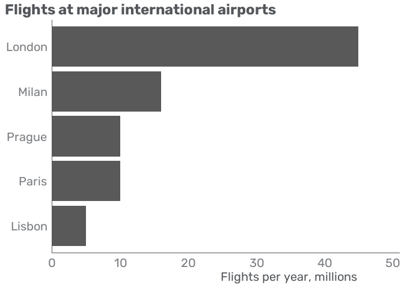

```r
# example plot
last_plot() +
  scale_y_continuvps(
    name = "Flights per year, millions",
    labels = scales::label_number(scale = 1/1e6),
    limits = c(0,50e6))
```

```r
# Assign this plot a name for later use
airport_plot = last_plot()
```

## 6. Data labels

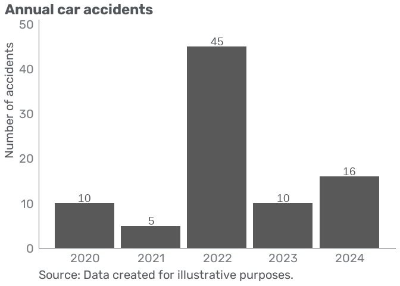

```r
# Add data labels
accident_plot +
  geom_text(
    aes(label = accidents),
    colour = bv.charcoal,
    vjust = -0.2, size = 5)
```

Data labels may not be required, such as when axis labels alone are enough if there are lots of categories (for example, bars), the differences are very clear, and individual values are not imperative.

Department guidelines require data labels to be placed on the left instead of the ends (right) of horizontal bars so the value of each bar is next to its axis/tick-mark label. This is easier to read vertically, as they all line up under each other, allows for quick, easy comparisons and doesn’t force the eye to jump back and forth, right to left.

We can achieve this by setting the y value for the labels at some value close to zero, so they are close to the axis rather than the end of the columns. The exaxt value will depend on your data. For our airports example, y = 3e6 works if we set hjust = 1. The latter ensures the final digit of each label is aligned.

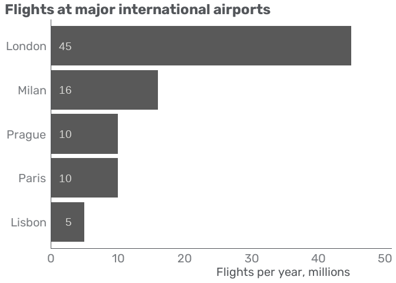

```r
# Add data labels
airport_plot +
  geom_text(
    aes(label = flights/1e6,
        y = 3e6),
    colour = bv.smoke,
    hjust = 1, size = 5)
```

# Using colour and fill scales from *vpstheme*

## 5. Colour

*vpstheme* includes named colours and palettes from the Brand Victoria guidelines, departmental colour palettes and departmental specfic colour and fill functions that allow us to add colour to our graphs.

The Department of Health’s primary colour, named `bv.pink` in *vpstheme* can be used as a fill by adding it as follows.

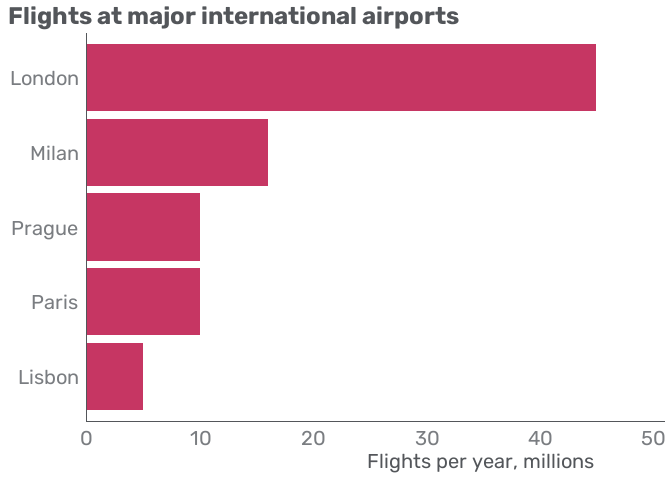

```r
airport_plot +
  geom_col(fill = bv.pink)
```

Departmental guidelines discourage the use of different colours. However, you may use different colours to:

- communicate different meanings in the data
- highlight important information by colouring it and using black or grey for all other bars.

We will illustrate how to do this using the features of *vpstheme*.

#### Highlighting

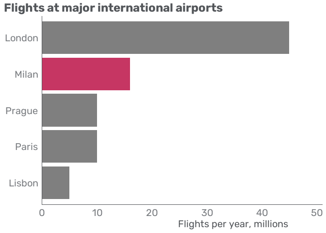

```r
airport_plot +
  geom_col(aes(fill = city)) +
  # Use scale_fill_manual to highlight Milan
  scale_fill_manual(values = c("Milan"=bv.pink), guide = "none")
```

Legends are not required if only one series of values in the graph and may not be required if data components can be labelled. This is preferred. We have hidden the legend in our example above by setting `guide = "none"`.

While departmental guidelines discourage the use of different colours, they do provide examples using shades of a single colour. *vpstheme* includes `scale_fill_dh` and `scale_fill_dh` that enable you to easily apply shades of the department’s primary palette to a chart (as well as more colourful discrete palettes to use where appropriate).

We revisit our accidents example, but add more detail to allow us to show how to use `scale_fill_dh` to create charts with shades of a single colour. Without `scale_fill_dh` our chart presents as follows.

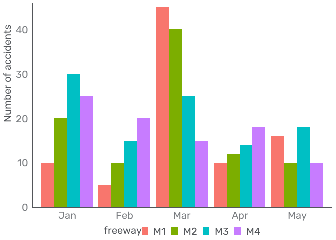

```r
# Create tibble of data for example
car_accidents =
  tibble::tibble(
    month = rep(c("Jan","Feb","Mar","Apr","May"),4),
    freeway = c(rep("M1",5),rep("M2",5),rep("M3",5),rep("M4",5)),
    accidents = c(10, 5, 45, 10, 16,
                  20, 10, 40, 12, 10,
                  30, 15, 25, 14, 18,
                  25, 20, 15, 18, 10)) |>
  dplyr::mutate(month = factor(month, levels = month.abb), freeway = factor(freeway))

# example of multi colour column plot
ggplot(data = car_accidents,
       aes(x = month,
           y = accidents,
           fill = freeway)) +
  # by default multi category columns will be stacked, we can adjust using `position`
  geom_col(position = position_dodge()) +
  theme_vps_dh() +
  scale_x_discrete(name = NULL) +
  scale_y_continuvps(name = "Number of accidents")
```

`scale_fill_dh` allows us to easily specify a palette comprised of departmental style guide compliant colours. We specify the `"pinks"` palette in the example below.

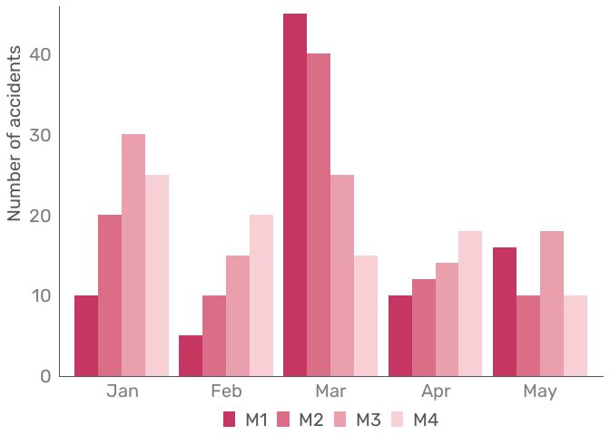

```r
last_plot() +
  # Add scale_fill_dh and specify the pinks palette
  scale_fill_dh(palette = "pinks", name = NULL)
```

For this example, a legend is required as we use multiple colours. Departmental guidelines recommend legends be placed as close as possible to content, below the title, close to the graph data (for example, at the end of a line) but not cluttering the plot area. Legend and plot margins in `theme_vps_dh()` have been set to achieve the recommended spacing, but can be adjusted using `theme()`.

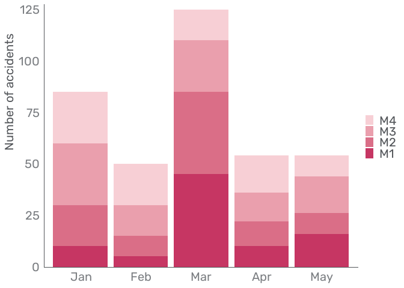

```r
last_plot() +
 # Change to a stacked bar chart
  geom_col(aes(fill = forcats::fct_rev(freeway)), position = position_stack()) +
  # Reverse oalette so colpours start from the bottom of each column
 # scale_fill_dh(palette = "pinks", name = NULL, reverse = TRUE) +
  guides(fill = guide_legend(reverse = TRUE))+
  # Move legend tot he right
  theme(legend.position = "right")
```

### Line charts

Departmental guidelines for using colour and legends in line charts differ to column/bar charts.

For line charts, it is recommended that you highlight a single line of interest by colouring it and using shades of black for other lines. The function `scale_colour_dh_line` has been created for this purpose. This scale creates a palette comprising a single colour and four shades of black. You can specify the colour (choosing from pink, blue, red and orange) and three different options for the shades of black (dark, light or gradient).

We create a new example to illustrate how to use `scale_colour_dh_line` as shown below. This highlights “Region A” while other regions are shown in grey.

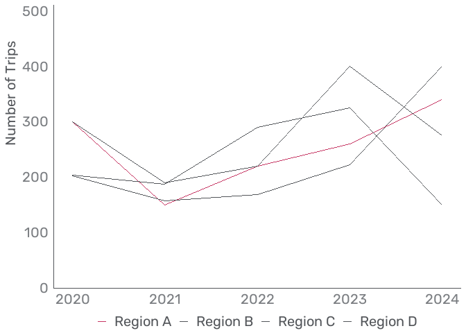

```r
# Line chart data
line_data =
  tibble(
    year =
      rep(2020:2024,5),
    Region =
      c(rep("Region A",5),
        rep("Region B",5),
        rep("Region C",5),
        rep("Region D",5),
        rep("Target",5)),
    trips =
      c(300,    150,    220,    260,    340,
        300,    190,    220,    400,    275,
        203,    157,    169,    223,    400,
        204,    187,    290,    325,    150,
        300,    300,    300,    300,    300)
  )

# example plot
ggplot(
  data = line_data |> filter(str_detect(Region, "Region")),
  aes(
    x = year,
    y = trips,
    fill = Region,
    colour = Region,
    )
  )+
  # Add line chart
  geom_line() +
  scale_x_continuous(name = NULL)+
  scale_y_continuvps(name = "Number of Trips", limits = c(0,500))+
  scale_colour_dh_line(name = NULL) +
  theme_vps_dh()
```

As noted previsously, department guidlines recommend legends be close to the graph data (for example, at the end of a line). We can achieve this style using `geom_text` as shown below. You will also need to adjust the spacing of the x axis. This can be done using `scale_x_continuvps`

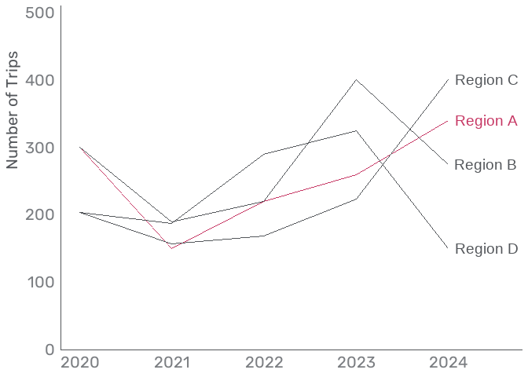

```r
# example plot
last_plot() +
  guides(colour = "none") +
  # Add labels using geom_text
  geom_text(
    data =  line_data |>
      # Filter data to only add labels for max(year)
      filter(str_detect(Region, "Region"),
             year == max(year)),
    aes(label = Region),
    size = 5,
    # Shift to right of x value.
    hjust = -.1) +
  # Use scale_x_continuvps to easily add space for label.
  scale_x_continuvps(name = NULL, expand_left = .05, expand_right = .2)
```

Other style guide recommendations include the use markers to show your actual data points to distinguish the series from a continuous distribution. We illustrate this and another option for `scale_colour_dh_line` below.

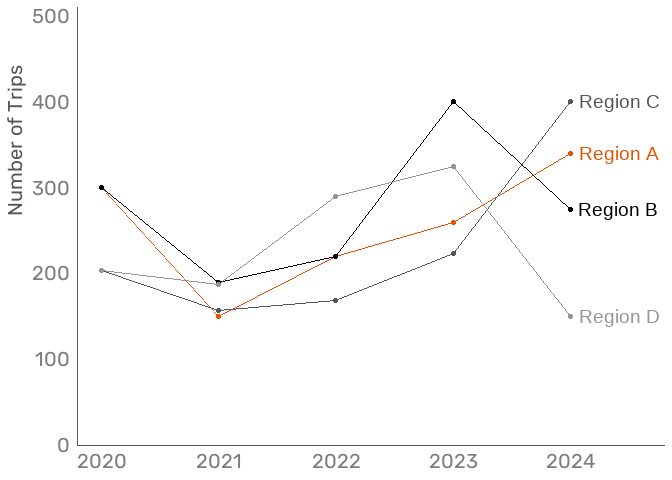

```r
# example plot
last_plot() +
  geom_point(show.legend = FALSE) +
  scale_colour_dh_line(guide = "none", colour = "orange", gradient = TRUE)
```

## 4. Scales

Accurately representing scales is important to ensure the data is telling the story you intend and not a different or misleading story.

Departmental guidance suggests quantitative scales (most often the vertical scale) should start at 0 on bar graphs. This is consistent with the `geometry of graphs` that governs `ggplot()` - limiting the scale to values above zero will prevent bars from showing.

The decision to start a scale at 0 on other graphs will depend on the situation.

## 7. Gridlines

May not be required. However, should you choose to include them to help users read and compare values if differences in data are hard to perceive, then this is accommodated in `theme_vps_dh()`. Setting `show_gridlines = TRUE` will add gridlines to the vertical axis.

Consistent with departmental guidelines that gridlines should be muted (light) relative to the data, the colour used is the same as axis labels.

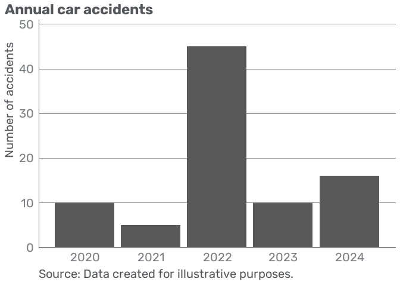

```r
accident_plot +
  theme_vps_dh(show_gridlines = TRUE)
```

## Other examples (in development).

The examples below show how to highlight one value with labels when using position_dodge using either `geom_text()` or `facet_grid()`.

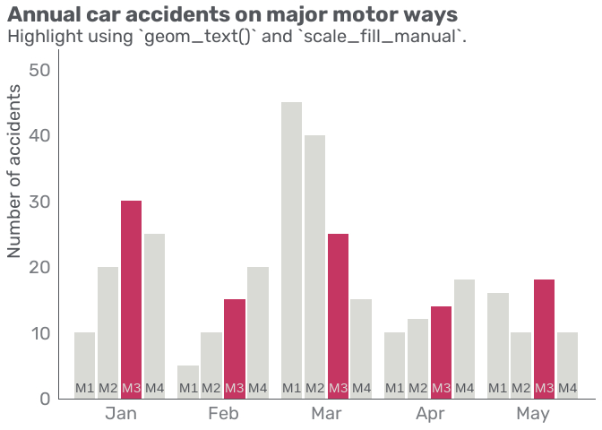

```r
ggplot2::ggplot(
  data = car_accidents,
  aes(x = month, y = accidents, fill = freeway,
      # Add label and colour aesthetics, the latter so we can specify different colours for
      # different label/backgroud combinations
      label = freeway, colour = freeway)) +
  # Add colour = 'transparent` so geom_col doesn't pick up the values of scale_colour_manual.
  geom_col(position = position_dodge2(), colour = "transparent") +
  # Add labels, but define arbitrary low value of y to place at base of columns.
  geom_text(
    aes(y = 1),
    # We need to set position to match geom_col()
    position = position_dodge2(width = .9),
    vjust = 0
    ) +
  scale_x_discrete(name = NULL)+
  scale_y_continuous(name = "Number of accidents", expand = c(0,0), limits=c(0,53))+
  # Use scale fill and specify the value you want to highlight and the value to use for others
  # na.value
  scale_fill_manual(guide = "none", values = c("M3" = bv.pink), na.value = bv.smoke)+
  # Use scale colour and specify the value you want to highlight and the value to use for others
  # na.value
  scale_colour_manual(guide = "none", values = c("M3" = bv.smoke), na.value = bv.charcoal)+
  labs(title="Annual car accidents on major motor ways",
       subtitle = "Highlight using `geom_text()` and `scale_fill_manual`.")+
  theme_vps_dh()
```

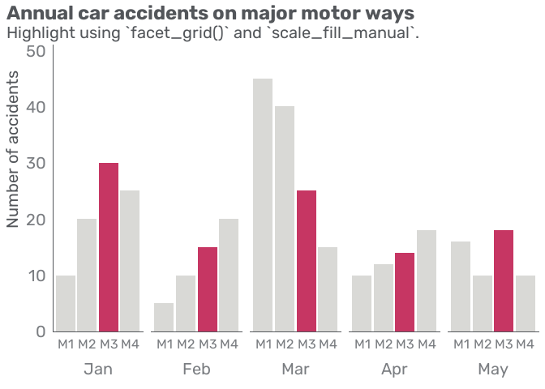

```r
ggplot2::ggplot(
  data = car_accidents,
  # Change our x aesthetic to freeway
  aes(x = freeway, y = accidents, fill = freeway)) +
  geom_col(position = position_dodge2()) +
  # Add facet_grid to reintroduce month, and use switch to put facet strips at bottom
  facet_grid(cols = vars(month), switch = "x") +
  scale_x_discrete(name = NULL)+
  scale_y_continuvps(name = "Number of accidents", limits = c(0,50))+
  # Use scale fill and specify the value you want to highlight and the value to use for others
  # na.value
  scale_fill_manual(guide = "none", values = c("M3" = bv.pink), na.value = bv.smoke)+
  labs(title="Annual car accidents on major motor ways",
       subtitle = "Highlight using `facet_grid()` and `scale_fill_manual`.")+
  theme_vps_dh() +
  # Adjust text size to fit axis labels
  theme(axis.text.x = element_text(size = rel(.8)))
```